# Adri’s Final Project

ECO602 Fall 2022

Adri Grow

12/17/2022

Final Project: Index

# R Reference Guide

## Loading Data and Packages

To load the palmer penguins dataset, you must load it into your R workspace.

- `library()` and `require()` are both functions which ensure the package is installed and can be used

```r
# Load and require the here package
library(here)
require(here)
# Load and require the palmerpenguins package
library(palmerpenguins)
require(palmerpenguins)
# Load the penguin data from the palmerpenguins package into a data frame called penguins
penguins <- palmerpenguins::penguins
```

To load a dataset into R, we’ll use the `here()` and `read.csv()` functions.

- `here()` tells R where we want to access the files from on the physical computer
- `read.csv()` transforms the raw data file into an R `data.frame` of columns and rows
- we’ll use the `<-` assignment operator to name our data to a `data.frame` called `ginkgo`

```r
ginkgo <- read.csv(here("./docs/ginkgo_data_2022.csv"))
```

## Data structures

The function `c()` combines or concatenates its arguments into a vector (a 1-dimensional data structure consisting of 1 or more elements).

All of the elements must be of the same type. I can’t combine character and numeric types in the same call to `c()` Here’s two examples using numeric and character data types:

```r
## Create a vector of numbers:
num_vec  = c(1, 4, 8, 9, 13)

## Create a vector of characters:
char_vec = c("a", "fish", "data is cool")
```

I can show the contents of a vector by typing the name of the vector, or using the `print()` function.

```r
## Typing the name of the vector into the console prints the contents
num_vec
```

```
## [1]  1  4  8  9 13
```

```r
## The print() function accomplishes the same task:
print(char_vec)
```

```
## [1] "a"            "fish"         "data is cool"
```

The function `length()` can report of set the length of a vector (or a factor or other R objects). I can find the length of the vectors we made above with the `length()` function:

```r
length(num_vec)
```

```
## [1] 5
```

```r
length(char_vec)
```

```
## [1] 3
```

```r
matrix1 <- matrix(1:10, nrow = 10)
print(matrix1)
```

```
##       [,1]
##  [1,]    1
##  [2,]    2
##  [3,]    3
##  [4,]    4
##  [5,]    5
##  [6,]    6
##  [7,]    7
##  [8,]    8
##  [9,]    9
## [10,]   10
```

The function `data.frame` creates a data frame of variables organized in columns and rows. This is the most basic R structure used.

*Inside the `data.frame()` function, I’m assigning values (contents of rows) to column names

```r
protists <- data.frame(
  Cell = c(1:5),
  Organism = c("Foram", "Ciliate", "Testate Amoeba", "Diatom", "Slime mold"),
  Typically_shelled = c("yes", "no", "yes", "yes", "no"),
  Cute = c("yes", "yes", "yes", "yes", "yes")
)
print(protists)
```

```
##   Cell       Organism Typically_shelled Cute
## 1    1          Foram               yes  yes
## 2    2        Ciliate                no  yes
## 3    3 Testate Amoeba               yes  yes
## 4    4         Diatom               yes  yes
## 5    5     Slime mold                no  yes
```

Using the Ginkgo 2022 that we loaded above, we can use the `nrow()`, `ncol()`, and `dim()` functions to get information about the data.

- `nrow()` gives the number of rows in the data frame
- `ncol()` gives the number of columns in the data frame
- `dim()` gives the dimensions of the data frame object

```r
nrow(ginkgo)
```

```
## [1] 220
```

```r
ncol(ginkgo)
```

```
## [1] 6
```

```r
dim(ginkgo)
```

```
## [1] 220   6
```

## Subsetting

I will use the `ginkgo` data frame to show an example of how we can extract a specific column of the data (called subsetting). I’m saving the subsetted data into a new data frame called `ginkgo_seeds`

```r
ginkgo_seeds <- data.frame(ginkgo$seeds_present)
```

I can also subset the data frame to target a specfic range of data. In the next three examples, I will select the first row, the element in row 2, column 3, and then the third column

```r
ginkgo_1st_row <- data.frame(ginkgo[1,])
print(ginkgo_1st_row)
```

```
##   site_id seeds_present max_width max_depth notch_depth petiole_length
## 1     216         FALSE        85        59          12             91
```

```r
ginkgo_row2col3 <- data.frame(ginkgo[2,3])
print(ginkgo_row2col3)
```

```
##   ginkgo.2..3.
## 1           72
```

```r
ginkgo_3rd_col <- data.frame(ginkgo[3])
head(ginkgo_3rd_col)
```

```
##   max_width
## 1        85
## 2        72
## 3        64
## 4        76
## 5        85
## 6        75
```

Note: I used the `head()` function to view the first few rows of the `ginkgo_3rd_col` data frame (rather than printing the entire column with 220 rows)

Next, I’ll use the `subset()` function to select all the Adelie penguin data from the penguins data frame we created earlier with the palmerpenguins package.

- `subset()` returns the data that meets the specified conditions

I’m using `==` to specify that I only want the data for species that are Adelie penguins.

```r
Adelie_penguins <- subset(penguins, species=="Adelie")
head(Adelie_penguins)
```

```
## # A tibble: 6 x 8
##   species island bill_length_mm bill_depth_mm flipper_length_… body_mass_g sex
##   <fct>   <fct>           <dbl>         <dbl>            <int>       <int> <fct>
## 1 Adelie  Torge…           39.1          18.7              181        3750 male
## 2 Adelie  Torge…           39.5          17.4              186        3800 fema…
## 3 Adelie  Torge…           40.3          18                195        3250 fema…
## 4 Adelie  Torge…           NA            NA                 NA          NA <NA>
## 5 Adelie  Torge…           36.7          19.3              193        3450 fema…
## 6 Adelie  Torge…           39.3          20.6              190        3650 male
## # … with 1 more variable: year <int>
```

## Numerical Data Exploration

Next I’ll use the `summary()`, `mean()`, and `sd()` functions to get some descriptive statistics for the ginkgo dataset. I’m specifically interested in the maximum width of the ginkgo leaves variable.

- `summary()` provides a summary of the data specified, for numeric variables this includes the minimum, median, mean, maximum
- `mean()` calculates the mean for the data specified
- `sd()` calculates the standard deviation for the data specified

```r
summary(ginkgo$max_width)
```

```
##    Min. 1st Qu.  Median    Mean 3rd Qu.    Max.
##   35.00   67.00   80.00   79.95   93.00  145.00
```

```r
mean(ginkgo$max_width)
```

```
## [1] 79.95455
```

```r
sd(ginkgo$max_width)
```

```
## [1] 18.16358
```

## Graphical Data Exploration

I will create a scatterplot of the ginkgo data. I’m interested in looking at the relationship between maximum leaf depth and maximum leaf width

- the `plot()` function is used to make a scatterplot
- `col=` change the color of the points (color name must be in quotes)
- `pch=` change the shape of the points
- `cex=` change the size of the points
- `main=` add a title to the plot
- `xlab=` add an x-axis label
- `ylab=` add a y-axis label
- `xlim=` set the x-axis coordinates
- `ylim=` set the y-axis coordinates

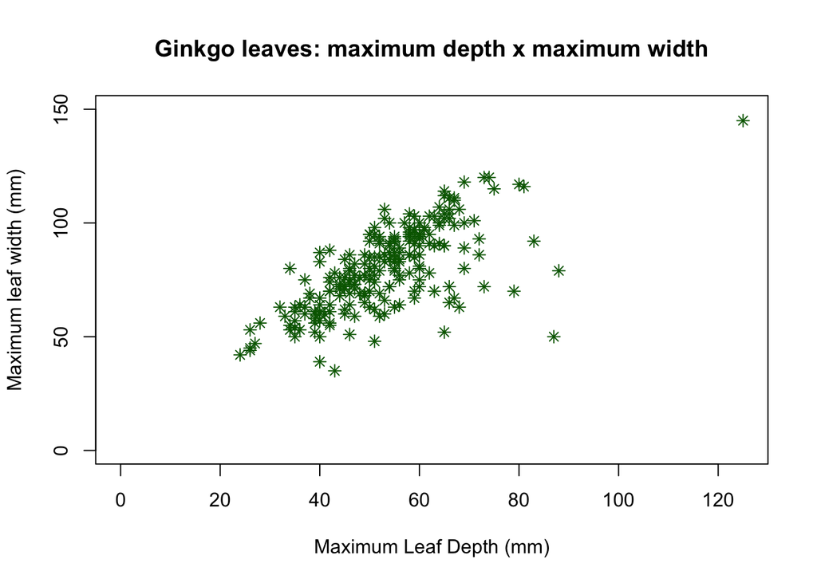

```r
plot(ginkgo$max_depth, ginkgo$max_width,
     col="darkgreen",
     pch = 8,
     cex = 1,
     main = "Ginkgo leaves: maximum depth x maximum width",
     xlab = "Maximum Leaf Depth (mm)",
     ylab = "Maximum leaf width (mm)",
     xlim=c(0,125),
     ylim=c(0,150))
```

I will create a histogram next with the palmer penguin data, specifically looking at the flipper lengths.

- the `hist()` function is used to make a historgram
- the `breaks()` functions is used to specify the number of bins you want the data separated into

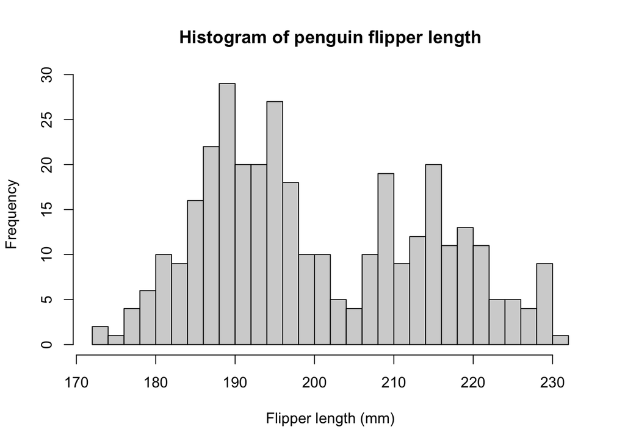

```r
hist(penguins$flipper_length_mm, breaks = 30, xlab="Flipper length (mm)", main="Histogram of penguin flipper length")
```

I will create a simple boxplot next with the ginkgo data, to specifically visualize the ginkgo petiole length.

- the `boxplot()` function is used to make a boxplot

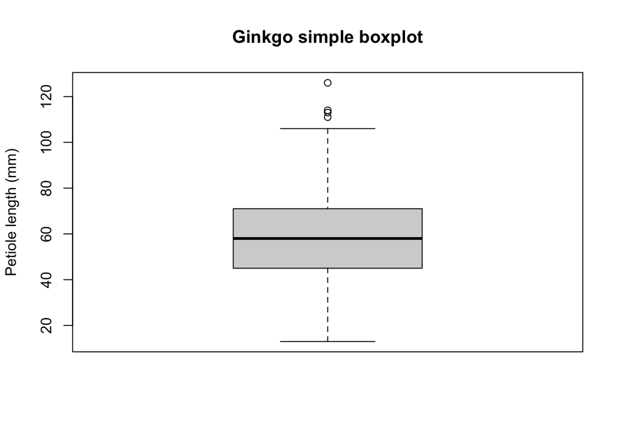

```r
boxplot(ginkgo$petiole_length, ylab = "Petiole length (mm)", main = "Ginkgo simple boxplot")
```

Next, I’ll make a conditional boxplot so that we can visualize a numerical variable (`max_width`) against a nominal variable (`seeds_present`).

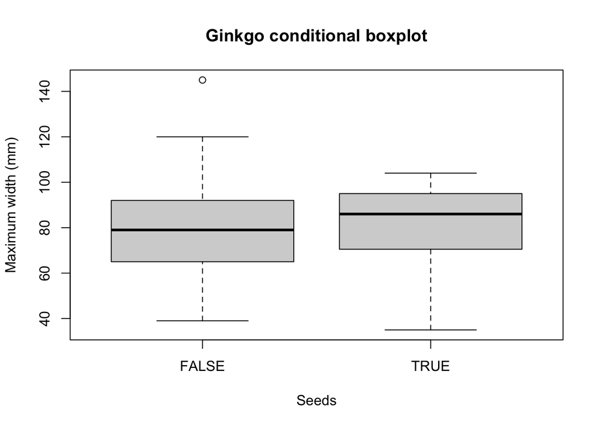

```r
boxplot(max_width ~ seeds_present, data = ginkgo, main = "Ginkgo conditional boxplot", xlab = "Seeds", ylab = "Maximum width (mm)")
```

Finally, I’ll make a panel of histograms so that we can visualize many plots of the ginkgo data at once.

- the `par()` function is used to set graphical parameters. In our case we want a 2x2 grid and will use the `mfrow()` function argument to specify 2 columns and 2 rows

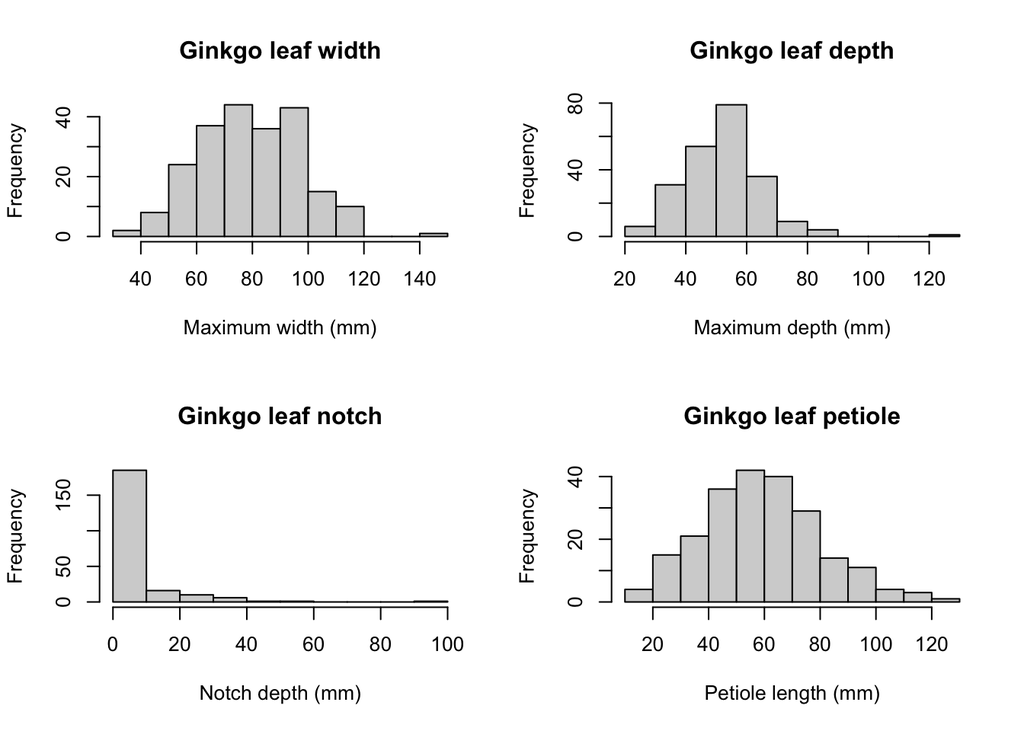

```r
par(mfrow=c(2,2))
hist(ginkgo$max_width, xlab = "Maximum width (mm)", main = "Ginkgo leaf width")
hist(ginkgo$max_depth, xlab = "Maximum depth (mm)", main = "Ginkgo leaf depth")
hist(ginkgo$notch_depth, xlab = "Notch depth (mm)", main = "Ginkgo leaf notch")
hist(ginkgo$petiole_length, xlab = "Petiole length (mm)", main = "Ginkgo leaf petiole")
```

## Distribution Functions

I’ll next show examples for six different distribution functions.

The three normal distribution functions are:

- `dnorm()` provides the density; dnorm(x, mean, sd)
  - use this if you want to know if a specific value is more likely
- `pnorm()` provides the distribution function; pnorm(q, mean, sd)
  - use this if you want to know the probability of a value within a specified range
- `qnorm()` provides the quantile function; qnorm(p, mean, sd)
  - use this if you want to ask about a certain percentile

```r
# What is the value of the standard normal distribution at x=1 with a normally-distributed population with mean = 3 and standard deviation = 1.7
dnorm(1, 3, 1.7)
```

```
## [1] 0.1174658
```

```r
# What is the probability of observing a value of less than 1.5 from a normally-distributed population with mean = 3 and standard deviation = 1.7?
pnorm(1.5, 3, 1.7)
```

```
## [1] 0.188793
```

```r
# find the 95th percentile of the standard normal distribution
qnorm(.95, 3, 1.7)
```

```
## [1] 5.796251
```

The three binomial distribution functions are:

- `dbinom()` provides the probability mass function; dbinom(x, size, prob)
  - use this if you want to know the probability of getting a value of exactly `x`
- `pbinom()` provides the cumulative mass function; pbinom(q, size, prob)
  - use this if you want to know the probability of getting a value of `x` or less or more
- `qbinom()` provides the quantile function; qbinom(q, size, prob)
  - use this if you want to ask about a certain percentile

```r
# Adri makes 70% of their free-throw attempts. If they shoot 15 free throws, what is the probability that they makes exactly 10?
# we want to find the probability of 10 successes during 15 trials where the probability of success on each trial is 0.7
dbinom(10, 15, 0.7)
```

```
## [1] 0.2061304
```

```r
# Jailene flips a coin 10 times. What is the probability that the coin lands on heads more than 5 times?
# we want to find the probability of more than 5 successes during 10 trials where the probability of success on each trial is 0.5
pbinom(5, size=10, prob=.5, lower.tail=FALSE)
```

```
## [1] 0.3769531
```

```r
# we want to find the 90th percentile of a binomial distribution with 50 trials and probability of success for each trial is 0.50
qbinom(.90, size=50, prob=.50)
```

```
## [1] 30
```